# SAT Score Distribution

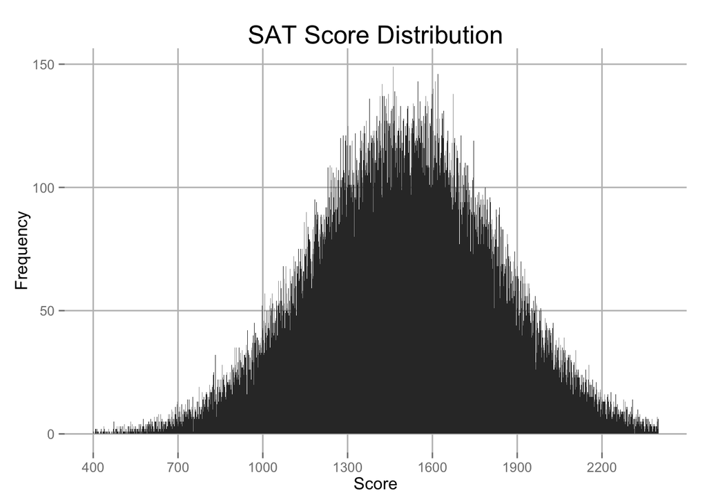

```r
frequency <- as.data.frame(table(testscores$scores))
colnames(frequency) <- c("scores", "frequency")
merge <- merge(testscores, frequency, by="scores")

ggplot(merge, aes(scores)) + geom_histogram(binwidth=1) + theme(panel.grid.minor = element_blank(), panel.grid.major = element_line(colour = "gray"), panel.background = element_rect(fill="white"), plot.title = element_text(size=rel(1.5))) + labs(title="SAT Score Distribution", x="Score", y="Frequency") + scale_x_continuous(breaks=seq(400,2400,300))
```

**The prank() Function**  
The *prank()* data transformation is a short hand for the word “percent rank”. In a vector of numerical values, *prank()* is used to calculate the proportion of data entries that a specific data entry is greater than or equal to. For example, in the list {1,5,6,7}, the entry ‘6’ has a prank of 75% because it is greater than or equal to 3 out of 4 of the list’s elements. Since the R programming language does not have a specific prank() function, we calculate prank(scores) by (rank of a score/total scores)*100. We then assign each value in the distribution its percent rank. Below, we’ve used prank() to color our distribution of SAT Scores.

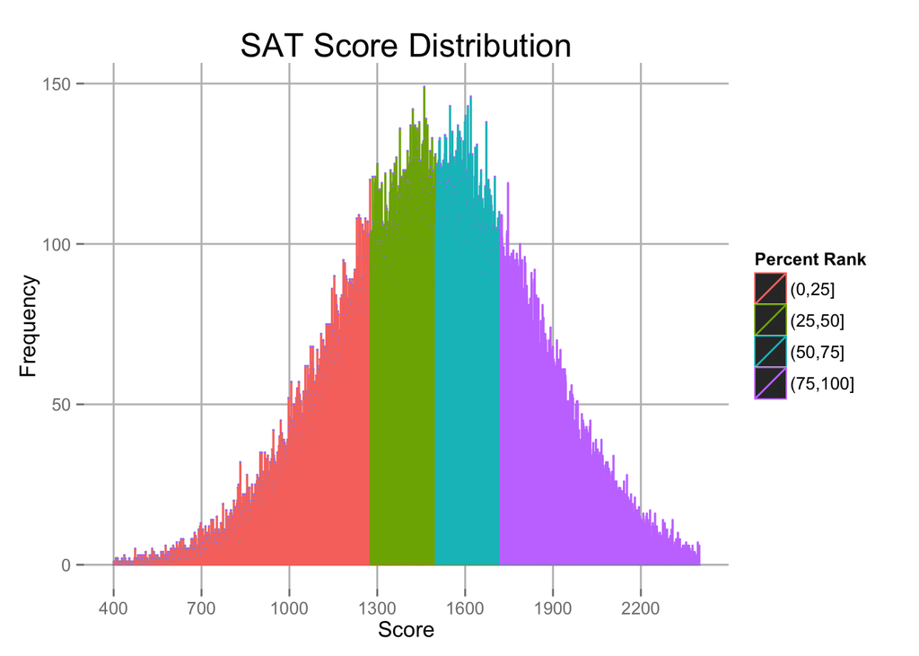

```r
#use of rank() data transformation
merge$rank <- rank(merge$scores)

#use rank to find percent rank - or prank() data transformation
merge$prank <- 100*(rank(merge$scores)/length(merge$scores))

#use of cut() to create percent range bins
merge$cutprank <- cut(merge$prank, breaks = seq(0, 100, by = 25))

#plot frequency distribution with color by percent rank.
ggplot(merge, aes(scores)) + geom_histogram(binwidth=1, aes(colour=cutprank)) + theme(panel.grid.minor = element_blank(), panel.grid.major = element_line(colour = "gray"), panel.background = element_rect(fill="white"), plot.title = element_text(size=rel(1.5))) + labs(title="SAT Score Distribution", x="Score", y="Frequency") + guides(color=guide_legend(title="Percent Rank")) + scale_x_continuous(breaks=seq(400,2400,300))
```

With this information, it is easy to see in which percentile range a specific score falls. Another way we can use prank() to better visualize our SAT data is to just highlight one of the percent ranges by making only the top 25% of score frequencies green and the rest of the plot black.

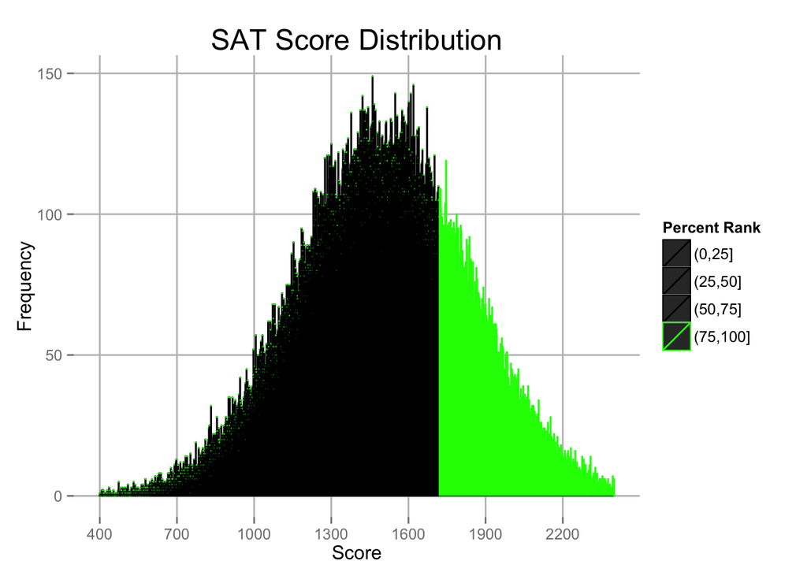

```r
#plot distribution with only the top 25% green
ggplot(merge, aes(scores)) + geom_histogram(binwidth = 1, aes(colour=cutprank)) + theme(panel.grid.minor = element_blank(), panel.grid.major = element_line(colour = "gray"), panel.background = element_rect(fill="white"), plot.title = element_text(size=rel(1.5))) + labs(title="SAT Score Distribution", x="Score", y="Frequency") + guides(color=guide_legend(title="Percent Rank")) + scale_colour_manual(values = c("black","black", "black", "green")) + scale_x_continuous(breaks=seq(400,2400,300))
```